# Experiment 1

Stas Sajin

October 10, 2015

# Synopsis

The aim of this document is to provide a summary of all the analyses used in writing up the results for Experiment 1 in the dissertation document.The analyses are brokwn down into several parts:

1. Data Cleaning and Pre-processing
2. Exploratory Analyses
3. Growth Curve Analysis
4. Graphs

#### *Libraries*

Load the required libraries

```r
library(ggplot2)
library(lme4)
library(lmerTest)
library(dplyr)
library(parallel)
library(doParallel)
library(tidyr)
library(gridExtra)
library(caret)
```

#### *Data Loading*

Not all colums in the results file are required. Only the following colums will be loaded in R, so as to preserve memory space. The colums are: RECORDING_SESSION_LABEL, IA_FIRST_RUN_START_TIME, IA_FIRST_RUN_START_TIME, IA_FIRST_RUN_END_TIME, IA_SECOND_RUN_START_TIME, IA_SECOND_RUN_END_TIME, IA_THIRD_RUN_START_TIME, IA_THIRD_RUN_END_TIME, IA_LABEL, RESPONSE_ACC, IA_DWELL_TIME, TRIAL_INDEX, target, RESPONSE_RT ,trialtype,target,Bilingual.

```r
EyeData <- read.csv("Exp1DriftCorrected.csv", na.strings = c("."))[,c('RECORDING_SESSION_LABEL', 'IA_FIRST_RUN_START_TIME', 'IA_FIRST_RUN_START_TIME', 'IA_FIRST_RUN_END_TIME', 'IA_SECOND_RUN_START_TIME', 'IA_SECOND_RUN_END_TIME', 'IA_THIRD_RUN_START_TIME', 'IA_THIRD_RUN_END_TIME', 'IA_LABEL', 'RESPONSE_ACC', 'IA_DWELL_TIME', 'TRIAL_INDEX', 'target', 'RESPONSE_RT', 'trialtype','Bilingual')]
#change all the NAs to zeros
EyeData[is.na(EyeData)] <- 0
#check the dimentions of the dataset
dim(EyeData)
```

```
## [1] 9564   16
```

```r
#rename the RECORDING_SESSION_LABEL into Subject
colnames(EyeData)[1] <- "Subject"
#examine colum names
names(EyeData)
```

```
##  [1] "Subject"                   "IA_FIRST_RUN_START_TIME"
##  [3] "IA_FIRST_RUN_START_TIME.1" "IA_FIRST_RUN_END_TIME"
##  [5] "IA_SECOND_RUN_START_TIME"  "IA_SECOND_RUN_END_TIME"
##  [7] "IA_THIRD_RUN_START_TIME"   "IA_THIRD_RUN_END_TIME"
##  [9] "IA_LABEL"                  "RESPONSE_ACC"
## [11] "IA_DWELL_TIME"             "TRIAL_INDEX"
## [13] "target"                    "RESPONSE_RT"
## [15] "trialtype"                 "Bilingual"
```

Examine the structure of the dataframe

```r
str(EyeData)
```

```
## 'data.frame':    9564 obs. of  16 variables:
##  $ Subject                  : Factor w/ 21 levels "e1s1","e1s10",..: 1 1 1 1 1 1 1 1 1 1 ...
##  $ IA_FIRST_RUN_START_TIME  : num  2576 4644 2040 1372 1680 ...
##  $ IA_FIRST_RUN_START_TIME.1: num  2576 4644 2040 1372 1680 ...
##  $ IA_FIRST_RUN_END_TIME    : num  2930 4938 2518 1666 1890 ...
##  $ IA_SECOND_RUN_START_TIME : num  6240 17748 11008 1876 3388 ...
##  $ IA_SECOND_RUN_END_TIME   : num  6426 18038 11042 1990 3874 ...
##  $ IA_THIRD_RUN_START_TIME  : num  11872 19372 11188 0 0 ...
##  $ IA_THIRD_RUN_END_TIME    : num  12106 19818 11390 0 0 ...
##  $ IA_LABEL                 : Factor w/ 4 levels "COMPET_IA ","TARGET_IA ",..: 2 1 3 4 2 1 3 4 2 1 ...
##  $ RESPONSE_ACC             : int  0 0 0 0 1 1 1 1 1 1 ...
##  $ IA_DWELL_TIME            : int  772 1120 736 412 700 528 352 340 636 384 ...
##  $ TRIAL_INDEX              : int  1 1 1 1 2 2 2 2 3 3 ...
##  $ target                   : Factor w/ 114 levels "agree","alarm",..: 31 31 31 31 104 104 104 104 100 100 ...
##  $ RESPONSE_RT              : num  18558 18558 18558 18558 1801 ...
##  $ trialtype                : Factor w/ 4 levels "Experimental",..: 4 4 4 4 4 4 4 4 4 4 ...
##  $ Bilingual                : Factor w/ 2 levels "no","yes": 1 1 1 1 1 1 1 1 1 1 ...
```

Everything looks fine.

## *Data Cleaning and PreProcessing*

Remove practice trials

```r
EyeData <- subset(EyeData, EyeData$trialtype!="Practice")
```

Check subject accuracy

```r
SubjectAccuracy<- EyeData %>% group_by(Subject) %>%
    summarise(MeanAccuracy=mean(RESPONSE_ACC)) %>% arrange(MeanAccuracy)
SubjectAccuracy
```

```
## Source: local data frame [21 x 2]
##
##    Subject MeanAccuracy
## 1     e1s1    0.9722222
## 2    e1s10    0.9906542
## 3    e1s11    1.0000000
## 4    e1s12    1.0000000
## 5    e1s13    1.0000000
## 6    e1s14    1.0000000
## 7    e1s15    1.0000000
## 8    e1s16    1.0000000
## 9    e1s17    1.0000000
## 10   e1s18    1.0000000
## ..     ...          ...
```

```r
SubjectRT<- EyeData %>% group_by(Subject) %>%
    summarise(MeanRT=mean(RESPONSE_RT)) %>% arrange(MeanRT)
SubjectRT
```

```
## Source: local data frame [21 x 2]
##
##    Subject   MeanRT
## 1     e1s5 1820.805
## 2     e1s2 1862.422
## 3     e1s1 1877.876
## 4    e1s15 1930.910
## 5    e1s10 1944.738
## 6    e1s13 1949.598
## 7     e1s6 1969.625
## 8    e1s18 1973.266
## 9    e1s12 2022.048
## 10    e1s3 2024.923
## ..     ...      ...
```

Subject accuracy is very high. Allmost all the subjects have 100% accuracy. Only 2 participants have a few incorrect trials.

Remove trials with incorrect accuracy

```r
CorrectEyeData<-EyeData %>% filter(RESPONSE_ACC==1)
```

Set up the start time and the end time dummy-coding of each run in the interest area. This creates colums where if a fixation exists during a run, then the run gets 1 (exists) or if there is no fixation in the IA during a run, then the coding is 0 (not exist)

```r
CorrectEyeData$Fststart <- ifelse(as.numeric(as.character(CorrectEyeData$IA_FIRST_RUN_START_TIME)) > 0, as.numeric(as.character(CorrectEyeData$IA_FIRST_RUN_START_TIME)), 0)
CorrectEyeData$Fstend <- ifelse(as.numeric(as.character(CorrectEyeData$IA_FIRST_RUN_START_TIME)) > 0, as.numeric(as.character(CorrectEyeData$IA_FIRST_RUN_END_TIME)), 0)
CorrectEyeData$Secstart <- ifelse(as.numeric(as.character(CorrectEyeData$IA_SECOND_RUN_START_TIME)) > 0, as.numeric(as.character(CorrectEyeData$IA_SECOND_RUN_START_TIME)), 0)
CorrectEyeData$Secend <- ifelse(as.numeric(as.character(CorrectEyeData$IA_SECOND_RUN_START_TIME)) > 0, as.numeric(as.character(CorrectEyeData$IA_SECOND_RUN_END_TIME)), 0)
CorrectEyeData$Thirdstart <- ifelse(as.numeric(as.character(CorrectEyeData$IA_THIRD_RUN_START_TIME)) > 0, as.numeric(as.character(CorrectEyeData$IA_THIRD_RUN_START_TIME)), 0)
CorrectEyeData$Thirdend <- ifelse(as.numeric(as.character(CorrectEyeData$IA_THIRD_RUN_START_TIME)) > 0, as.numeric(as.character(CorrectEyeData$IA_THIRD_RUN_END_TIME)), 0)
```

Generate time bins from time 0 to time 6000 in 25 ms bins and assign them to the dataset

```r
time <- seq(0, 6000, by=25)
tmatrix <- matrix(nrow=nrow(CorrectEyeData), ncol=length(time))
dim(tmatrix)
```

```
## [1] 9044  241
```

Generate time vectors for each row and column for first, second, and third pass viewings so that viewing periods receive a viewing probability value of 1

```r
registerDoParallel(3)
for(i in 1:nrow(tmatrix)) {
for(j in 1:length(time)) {

tmatrix[i,j] <-  ifelse(CorrectEyeData$Fststart[i] < time[j] &
                CorrectEyeData$Fstend[i] > time[j] |CorrectEyeData$Secstart[i] <
                time[j] & CorrectEyeData$Secend[i] > time[j] | CorrectEyeData$Thirdstart[i]
                < time[j] & CorrectEyeData$Thirdend[i]>time[j], 1,0)
}
}
```

Combine the CleanEyeData with the time matrix

```r
CleanData <- cbind(CorrectEyeData, data.frame(tmatrix))
```

Assign time values to time bin columns

```r
colnames(CleanData)[23:263] <- seq(0, 6000, by=25)
```

Subset the dataset with only the necessary colums and remove anything in the memory that might be a memory hog

```r
CleanData <- CleanData[, -c(2:8,10,11,17:22)]
```

Put the data in long-format and then calculate the proportion for each time bin for each subject

```r
CleanData<- CleanData %>% gather(time,value,8:248)
#find proportion for each interest area for each subject
CleanDataProb<-CleanData %>% group_by(Subject,Bilingual,IA_LABEL,trialtype,time) %>%
    summarise(Prob=mean(value))
CleanDataProb$time<-as.numeric(as.character(CleanDataProb$time))
```

## **Exploratory Graphs**

The aim of this section is to explore pattern in the data without commiting to any formal modeling. Several questions will be addressed thoguh exploratory graphs 1. What participants do during the period before the onset of the word is presented?

2. Are participants’s attention drawn to similar orthographic words before the onset of the target?
3. Is having bilinguals in this experiment an issue? There were 3 subjects who reported being bilingual, though they spoke English at home.

```r
#subset the required dataset by averaging over subjects; find the usual
OnlySubjects<-CleanData %>% group_by(IA_LABEL,trialtype,time) %>%
    summarise(n=n(),Prob=mean(value),sd=sd(value)) %>%
    mutate(se=sd/sqrt(n), LCI=Prob+qnorm(0.025)*se, UCI=Prob+qnorm(0.975)*se)
OnlySubjects$time<-as.numeric(as.character(OnlySubjects$time))

levels(OnlySubjects$IA_LABEL) <- list(Target="TARGET_IA ", Competitor="COMPET_IA ", Distractor1="UNREL1_IA ", Distractor2="UNREL2_IA ")
colnames(OnlySubjects)[1]<-"Interest Area"
```

```r
#plot for time 0 to time 6000
cbPalette <- c("#999999", "#E69F00", "#56B4E9", "#009E73", "#F0E442", "#0072B2", "#D55E00", "#CC79A7")
g1<-ggplot(OnlySubjects, aes(x=time, y=Prob, shape=`Interest Area`, color=`Interest Area`)) +
    geom_point(size=3) +
    geom_errorbar(aes(ymin=LCI, ymax=UCI)) + facet_grid(.~trialtype)+
    scale_x_continuous(limits = c(0, 6000))+
    geom_vline(xintercept = 3082)+
    geom_vline(xintercept = 4000)+theme_bw()+
    scale_fill_manual(values=cbPalette)+scale_colour_manual(values=cbPalette)+
    scale_x_continuous(name="time from onset of fixation cross(ms)")+
    scale_y_continuous(name="Fixation Proportion")+
    theme(legend.text = element_text(size = 12))+
    theme(legend.title = element_text(size=12, face="bold"))+
    theme(legend.title = element_text(size=12, face="bold"))+
    theme(axis.title.x = element_text(face="bold", size=15), axis.text.x  = element_text(size=10))+
    theme(axis.title.y = element_text(face="bold", size=15), axis.text.y  = element_text(size=10))+
    theme(strip.text.x = element_text(size=12, face="bold"))+
    theme(plot.title = element_text(lineheight=.8, face="bold", size=14))

#plot from time 1000(fixation cross)+1000(word display with no sound)+682(click on duration)+200(pause duration)+200(time it takes to initiate fixation. This plots the fixations starting from the onset of the word till about 3750ms.
g2<-ggplot(OnlySubjects, aes(x=time, y=Prob, shape=`Interest Area`, color=`Interest Area`)) +
    geom_point(size=3) +
    geom_errorbar(aes(ymin=LCI, ymax=UCI)) + facet_grid(.~trialtype)+
    scale_x_continuous(limits = c(1000+1000+682+200+200, 4000), name="time 200ms from spoken word onset(ms)")+
    theme_bw()+
    scale_fill_manual(values=cbPalette)+scale_colour_manual(values=cbPalette)+
    scale_y_continuous(name="Fixation Proportion")+
    theme(legend.position="none")+
    theme(axis.title.x = element_text(face="bold", size=15), axis.text.x  = element_text(size=10))+
    theme(axis.title.y = element_text(face="bold", size=15), axis.text.y  = element_text(size=10))+
    theme(plot.title = element_text(lineheight=.8, face="bold", size=14))+
    theme(strip.text.x = element_text(size=12, face="bold"))

png(filename="plot3Experiment1.png",width=900,height=524)
grid.arrange(g1, g2, nrow=2, ncol=1, top="Fixation proportion for each trial type")
dev.off()
```

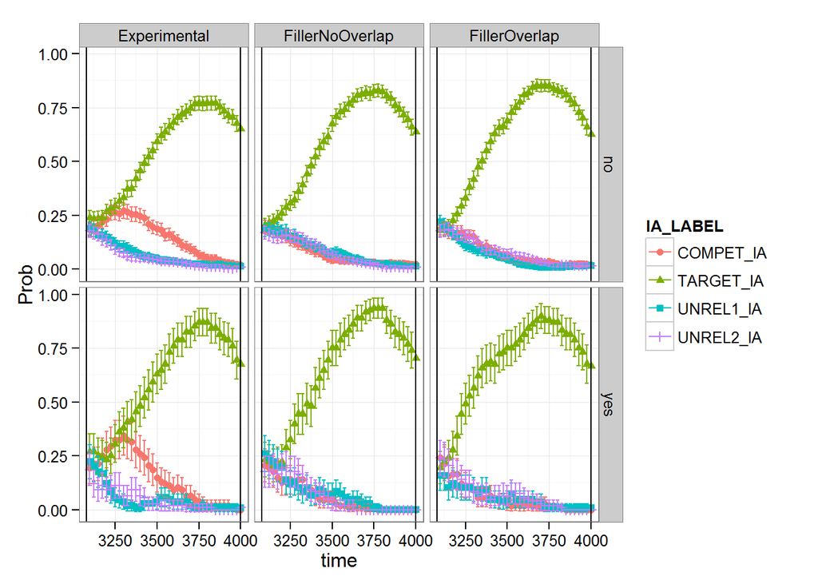

```r
OnlySubjectsB<-CleanData %>% group_by(Bilingual,IA_LABEL,trialtype,time) %>%
    summarise(n=n(),Prob=mean(value),sd=sd(value)) %>%
    mutate(se=sd/sqrt(n), LCI=Prob+qnorm(0.025)*se, UCI=Prob+qnorm(0.975)*se)
OnlySubjectsB$time<-as.numeric(as.character(OnlySubjectsB$time))

ggplot(OnlySubjectsB, aes(x=time, y=Prob, shape=IA_LABEL, color=IA_LABEL)) +
    geom_point() +
    geom_errorbar(aes(ymin=LCI, ymax=UCI)) + facet_grid(Bilingual~trialtype)+
    scale_x_continuous(limits = c(1000+1000+682+200+200, 4000))+
    geom_vline(xintercept = 3082)+
    geom_vline(xintercept = 4000)+theme_bw()
```

There doesn’t seem to be any substantial differences between bilinguals and natives. There are only 3 bilingual subjects, so the ammount of variability for bilingual is larger, but other than that, there is nothing to suggest that these subjects should be removed.

## **Growth Curve Analyses**

The following analyses will examine 1. the proportion fixations between the Target and the Competitor in Experimental Trials 2. the proportion fixations between the Competitor and the average of the two distractors in Experimental Trials.

Exploratory graphs (see above) indicate that there are no effects are observed before the presentation of the speech onset, so proportions are examined from 3100 (about 218 ms after onset of the target) until 4000ms.

### *Target vs. Competitor*

First, the required subset for the `1st` analysis is created

```r
model<-CleanDataProb %>%
    filter(trialtype=="Experimental", IA_LABEL=="COMPET_IA " | IA_LABEL=="TARGET_IA ",
           time>=3100 & time <=4000)
model$IA_LABEL<-as.factor(as.character(model$IA_LABEL))

#Generate time polynomials up to quadratic poly.
t25 <- data.frame(poly(unique(model$time),4))
t25$time <- seq(3100, 4000, by=25)

#add polynomials to data frame
model <- merge(model , t25, by="time")
head(model)
```

```
##   time Subject Bilingual   IA_LABEL    trialtype      Prob         X1
## 1 3100    e1s1        no COMPET_IA  Experimental 0.1818182 -0.2771528
## 2 3100   e1s13       yes COMPET_IA  Experimental 0.1388889 -0.2771528
## 3 3100    e1s2        no TARGET_IA  Experimental 0.3055556 -0.2771528
## 4 3100   e1s14        no TARGET_IA  Experimental 0.3333333 -0.2771528
## 5 3100   e1s12        no TARGET_IA  Experimental 0.2500000 -0.2771528
## 6 3100    e1s6        no COMPET_IA  Experimental 0.2777778 -0.2771528
##          X2        X3        X4
## 1 0.3389575 -0.369759 0.3761457
## 2 0.3389575 -0.369759 0.3761457
## 3 0.3389575 -0.369759 0.3761457
## 4 0.3389575 -0.369759 0.3761457
## 5 0.3389575 -0.369759 0.3761457
## 6 0.3389575 -0.369759 0.3761457
```

```r
str(model)
```

```
## 'data.frame':    1554 obs. of  10 variables:
##  $ time     : num  3100 3100 3100 3100 3100 3100 3100 3100 3100 3100 ...
##  $ Subject  : Factor w/ 21 levels "e1s1","e1s10",..: 1 5 12 6 4 18 6 10 17 11 ...
##  $ Bilingual: Factor w/ 2 levels "no","yes": 1 2 1 1 1 1 1 1 1 1 ...
##  $ IA_LABEL : Factor w/ 2 levels "COMPET_IA ","TARGET_IA ": 1 1 2 2 2 1 1 1 2 2 ...
##  $ trialtype: Factor w/ 4 levels "Experimental",..: 1 1 1 1 1 1 1 1 1 1 ...
##  $ Prob     : num  0.182 0.139 0.306 0.333 0.25 ...
##  $ X1       : num  -0.277 -0.277 -0.277 -0.277 -0.277 ...
##  $ X2       : num  0.339 0.339 0.339 0.339 0.339 ...
##  $ X3       : num  -0.37 -0.37 -0.37 -0.37 -0.37 ...
##  $ X4       : num  0.376 0.376 0.376 0.376 0.376 ...
```

The following models are run, with increasing complexity:

Model 1: A base model with no polynomials and only with the fixed effect IA_LABEL and random effect of subject intercept and nested condition with subject intercept.

Model 2: Base model with the addition of the linear polynomial for the fixed and random effect structure

Model 3. Model above+the addition of the quadratic polynomial in the fixed effect and random effect structure

Model 4. Model 3+addition of the third poly in the fixed and random effect structure. Model fails to converge

Model 5. Model 4+addition of the third poly in the fixed and in the random structure(subject only)

Model 6. Model 5+addition of the third poly in the fixed and random structure(subject:condition only)

```r
registerDoParallel(3)
#base model; Model1
Model1<-lmer(Prob ~ IA_LABEL +
                 (1| Subject) +
                 (1| Subject:IA_LABEL),
               data=model, REML=T)
#linear; model 2
Model2<-lmer(Prob ~ IA_LABEL*X1 +
                 (1+X1| Subject) +
                 (1+X1| Subject:IA_LABEL),
               data=model, REML=T)
#linea+quadratic; model 3
Model3<-lmer(Prob ~ IA_LABEL*(X1+X2) +
                 (1+X1+X2| Subject) +
                 (1+X1+X2| Subject:IA_LABEL),
               data=model, REML=T)
#Model 4
Model4<-lmer(Prob ~ IA_LABEL*(X1+X2+X3) +
                 (1+X1+X2+X3| Subject) +
                 (1+X1+X2+X3| Subject:IA_LABEL),
               data=model, REML=T)
#Model 5
Model5<-lmer(Prob ~ IA_LABEL*(X1+X2+X3) +
                 (1+X1+X2+X3| Subject) +
                 (1+X1+X2| Subject:IA_LABEL),
               data=model, REML=T)
#Model 6
Model6<-lmer(Prob ~ IA_LABEL*(X1+X2+X3) +
                 (1+X1+X2| Subject) +
                 (1+X1+X2+X3| Subject:IA_LABEL),
               data=model, REML=T)
#compare the models based on ANOVA test
anova(Model1,Model2,Model3,Model4,Model5,Model6)
```

```
## Data: model
## Models:
## object: Prob ~ IA_LABEL + (1 | Subject) + (1 | Subject:IA_LABEL)
## ..1: Prob ~ IA_LABEL * X1 + (1 + X1 | Subject) + (1 + X1 | Subject:IA_LABEL)
## ..2: Prob ~ IA_LABEL * (X1 + X2) + (1 + X1 + X2 | Subject) + (1 +
## ..2:     X1 + X2 | Subject:IA_LABEL)
## ..4: Prob ~ IA_LABEL * (X1 + X2 + X3) + (1 + X1 + X2 + X3 | Subject) +
## ..4:     (1 + X1 + X2 | Subject:IA_LABEL)
## ..5: Prob ~ IA_LABEL * (X1 + X2 + X3) + (1 + X1 + X2 | Subject) +
## ..5:     (1 + X1 + X2 + X3 | Subject:IA_LABEL)
## ..3: Prob ~ IA_LABEL * (X1 + X2 + X3) + (1 + X1 + X2 + X3 | Subject) +
## ..3:     (1 + X1 + X2 + X3 | Subject:IA_LABEL)
##        Df     AIC     BIC  logLik deviance   Chisq Chi Df Pr(>Chisq)
## object  5  -997.7  -971.0  503.87  -1007.7
## ..1    11 -3091.9 -3033.0 1556.94  -3113.9 2106.15      6     <2e-16 ***
## ..2    19 -3925.5 -3823.9 1981.74  -3963.5  849.60      8     <2e-16 ***
## ..4    25 -4802.8 -4669.0 2426.38  -4852.8  889.27      6     <2e-16 ***
## ..5    25 -5075.0 -4941.3 2562.49  -5125.0  272.23      0     <2e-16 ***
## ..3    29 -5066.9 -4911.8 2562.46  -5124.9    0.00      4          1
## ---
## Signif. codes:  0 '***' 0.001 '**' 0.01 '*' 0.05 '.' 0.1 ' ' 1
```

```r
#compare the models based on R^2 based on a paper from Xu (http://onlinelibrary.wiley.com/doi/10.1002/sim.1572/abstract)
1-var(residuals(Model1))/(var(model.response(model.frame(Model1))))
```

```
## [1] 0.6064327
```

```r
1-var(residuals(Model2))/(var(model.response(model.frame(Model2))))
```

```
## [1] 0.9117757
```

```r
1-var(residuals(Model3))/(var(model.response(model.frame(Model3))))
```

```
## [1] 0.9546218
```

```r
1-var(residuals(Model4))/(var(model.response(model.frame(Model4))))
```

```
## [1] 0.9817423
```

```r
1-var(residuals(Model5))/(var(model.response(model.frame(Model5))))
```

```
## [1] 0.9765794
```

```r
1-var(residuals(Model6))/(var(model.response(model.frame(Model6))))
```

```
## [1] 0.9817424
```

```r
#find the summary for model 6
summary(Model6)
```

```
## Linear mixed model fit by REML t-tests use Satterthwaite approximations
##   to degrees of freedom [lmerMod]
## Formula: Prob ~ IA_LABEL * (X1 + X2 + X3) + (1 + X1 + X2 | Subject) +
##     (1 + X1 + X2 + X3 | Subject:IA_LABEL)
##    Data: model
##
## REML criterion at convergence: -5083.1
##
## Scaled residuals:
##     Min      1Q  Median      3Q     Max
## -3.2088 -0.5935 -0.0171  0.5712  3.2456
##
## Random effects:
##  Groups           Name        Variance  Std.Dev. Corr
##  Subject:IA_LABEL (Intercept) 2.516e-03 0.05016
##                   X1          9.378e-02 0.30624   0.24
##                   X2          2.837e-02 0.16843  -0.20  0.20
##                   X3          1.889e-02 0.13745  -0.21 -0.51 -0.05
##  Subject          (Intercept) 2.134e-05 0.00462
##                   X1          3.958e-04 0.01989  1.00
##                   X2          3.878e-03 0.06228  1.00  1.00
##  Residual                     1.507e-03 0.03882
## Number of obs: 1554, groups:  Subject:IA_LABEL, 42; Subject, 21
##
## Fixed effects:
##                       Estimate Std. Error       df t value Pr(>|t|)
## (Intercept)            0.14945    0.01108 40.09000  13.489 2.22e-16 ***
## IA_LABELTARGET_IA      0.41315    0.01560 39.21000  26.477  < 2e-16 ***
## X1                    -0.50128    0.06750 40.14000  -7.426 4.72e-09 ***
## X2                    -0.11789    0.04009 39.55000  -2.940  0.00545 **
## X3                     0.17711    0.03117 40.00000   5.683 1.32e-06 ***
## IA_LABELTARGET_IA :X1  1.60727    0.09526 39.35000  16.872  < 2e-16 ***
## IA_LABELTARGET_IA :X2 -0.27694    0.05334 23.27000  -5.192 2.80e-05 ***
## IA_LABELTARGET_IA :X3 -0.45544    0.04408 40.00000 -10.333 7.45e-13 ***
## ---
## Signif. codes:  0 '***' 0.001 '**' 0.01 '*' 0.05 '.' 0.1 ' ' 1
##
## Correlation of Fixed Effects:
##                      (Intr) IA_LAB X1     X2     X3
## IA_LABELTAR          -0.704
## X1                    0.239 -0.165
## X2                   -0.149  0.128  0.202
## X3                   -0.200  0.142 -0.487 -0.044
## IA_LABELTARGET_IA:X1 -0.165  0.234 -0.706 -0.128  0.345
## IA_LABELTARGET_IA:X2  0.135 -0.192 -0.135 -0.665  0.033
## IA_LABELTARGET_IA:X3  0.141 -0.201  0.344  0.031 -0.707
##                      IA_LABELTARGET_IA:X1 IA_LABELTARGET_IA:X2
## IA_LABELTAR
## X1
## X2
## X3
## IA_LABELTARGET_IA:X1
## IA_LABELTARGET_IA:X2  0.192
## IA_LABELTARGET_IA:X3 -0.488               -0.046
```

```r
#find the RMSE
sqrt(mean((model$Prob-fitted(Model6))^2))
```

```
## [1] 0.03676391
```

```r
#attach the fitted values to the dataset model, so that they can be used later for graphing purposes
model$Model1Fitted<-fitted(Model1)
model$Model2Fitted<-fitted(Model2)
model$Model3Fitted<-fitted(Model3)
model$Model4Fitted<-fitted(Model4)
model$Model5Fitted<-fitted(Model5)
model$Model6Fitted<-fitted(Model6)

#check that the values are in the dataset
str(model)
```

```
## 'data.frame':    1554 obs. of  16 variables:
##  $ time        : num  3100 3100 3100 3100 3100 3100 3100 3100 3100 3100 ...
##  $ Subject     : Factor w/ 21 levels "e1s1","e1s10",..: 1 5 12 6 4 18 6 10 17 11 ...
##  $ Bilingual   : Factor w/ 2 levels "no","yes": 1 2 1 1 1 1 1 1 1 1 ...
##  $ IA_LABEL    : Factor w/ 2 levels "COMPET_IA ","TARGET_IA ": 1 1 2 2 2 1 1 1 2 2 ...
##  $ trialtype   : Factor w/ 4 levels "Experimental",..: 1 1 1 1 1 1 1 1 1 1 ...
##  $ Prob        : num  0.182 0.139 0.306 0.333 0.25 ...
##  $ X1          : num  -0.277 -0.277 -0.277 -0.277 -0.277 ...
##  $ X2          : num  0.339 0.339 0.339 0.339 0.339 ...
##  $ X3          : num  -0.37 -0.37 -0.37 -0.37 -0.37 ...
##  $ X4          : num  0.376 0.376 0.376 0.376 0.376 ...
##  $ Model1Fitted: num  0.135 0.143 0.583 0.617 0.603 ...
##  $ Model2Fitted: num  0.283 0.302 0.335 0.292 0.291 ...
##  $ Model3Fitted: num  0.271 0.27 0.119 0.202 0.129 ...
##  $ Model4Fitted: num  0.233 0.147 0.255 0.266 0.238 ...
##  $ Model5Fitted: num  0.2 0.214 0.213 0.264 0.236 ...
##  $ Model6Fitted: num  0.233 0.147 0.256 0.266 0.238 ...
```

Model 6 performs the best, though LMER is not very susceptible to corss-validation, so the addition of more polynomials might be leading to overfitting

### *Compare LMER with Random Forests*

This portion of the report aims to examine if it is even necessary to have so many polynomials in the fixed effect structure of the LMER model used above. Two random forests models are fitted. The models are cross-validated.

The first models examines the inclusion of all 4 polynomials interacting with the IA_LABEL and the inclusion of Subject ID

```r
set.seed(123)
modelRF1<-train(Prob~(X1+X2+X3+X4)*IA_LABEL+Subject, method="rf", data=model,
                trControl = trainControl(method = "cv", number = 5),
                 ntree = 200, importance = TRUE)
#Examine Model Ouput
modelRF1
```

```
## Random Forest
##
## 1554 samples
##   15 predictor
##
## No pre-processing
## Resampling: Cross-Validated (5 fold)
##
## Summary of sample sizes: 1244, 1244, 1242, 1243, 1243
##
## Resampling results across tuning parameters:
##
##   mtry  RMSE        Rsquared   RMSE SD      Rsquared SD
##    2    0.08964386  0.9116720  0.002450369  0.005223231
##   15    0.04990486  0.9669208  0.002835811  0.004523342
##   29    0.05095493  0.9651894  0.003320167  0.005507019
##
## RMSE was used to select the optimal model using  the smallest value.
## The final value used for the model was mtry = 15.
```

```r
#Examine the best model
modelRF1$finalModel
```

```
##
## Call:
##  randomForest(x = x, y = y, ntree = 200, mtry = param$mtry, importance = TRUE)
##                Type of random forest: regression
##                      Number of trees: 200
## No. of variables tried at each split: 15
##
##           Mean of squared residuals: 0.00195862
##                     % Var explained: 97.35
```

```r
#Examine Variable Importance
modelRF1$finalModel$importance
```

```
##                            %IncMSE IncNodePurity
## X1                    0.0175489109    11.6240719
## X2                    0.0031341963     2.4085954
## X3                    0.0019527941     1.4473065
## X4                    0.0009405765     0.9140887
## IA_LABELTARGET_IA     0.0403720594    19.4476652
## Subjecte1s10          0.0003781288     0.3937572
## Subjecte1s11          0.0005273169     0.4474585
## Subjecte1s12          0.0002592072     0.1893412
## Subjecte1s13          0.0003467159     0.2737490
## Subjecte1s14          0.0003730672     0.2943546
## Subjecte1s15          0.0017321974     1.4529849
## Subjecte1s16          0.0005691606     0.5027679
## Subjecte1s17          0.0005014942     0.4116735
## Subjecte1s18          0.0005922526     0.5285781
## Subjecte1s19          0.0008082959     0.7401662
## Subjecte1s2           0.0001755766     0.2757416
## Subjecte1s20          0.0011424767     0.7543212
## Subjecte1s21          0.0005402116     0.4064176
## Subjecte1s3           0.0002326921     0.2157512
## Subjecte1s4           0.0003198402     0.2302879
## Subjecte1s5           0.0004696047     0.5443616
## Subjecte1s6           0.0011838399     0.7324861
## Subjecte1s7           0.0004965644     0.3393259
## Subjecte1s8           0.0004665593     0.4537908
## Subjecte1s9           0.0004354645     0.2952256
## X1:IA_LABELTARGET_IA  0.0689429279    47.7633937
## X2:IA_LABELTARGET_IA  0.0194390017    11.6510741
## X3:IA_LABELTARGET_IA  0.0108573280     7.1660941
## X4:IA_LABELTARGET_IA  0.0032555012     2.0207162
```

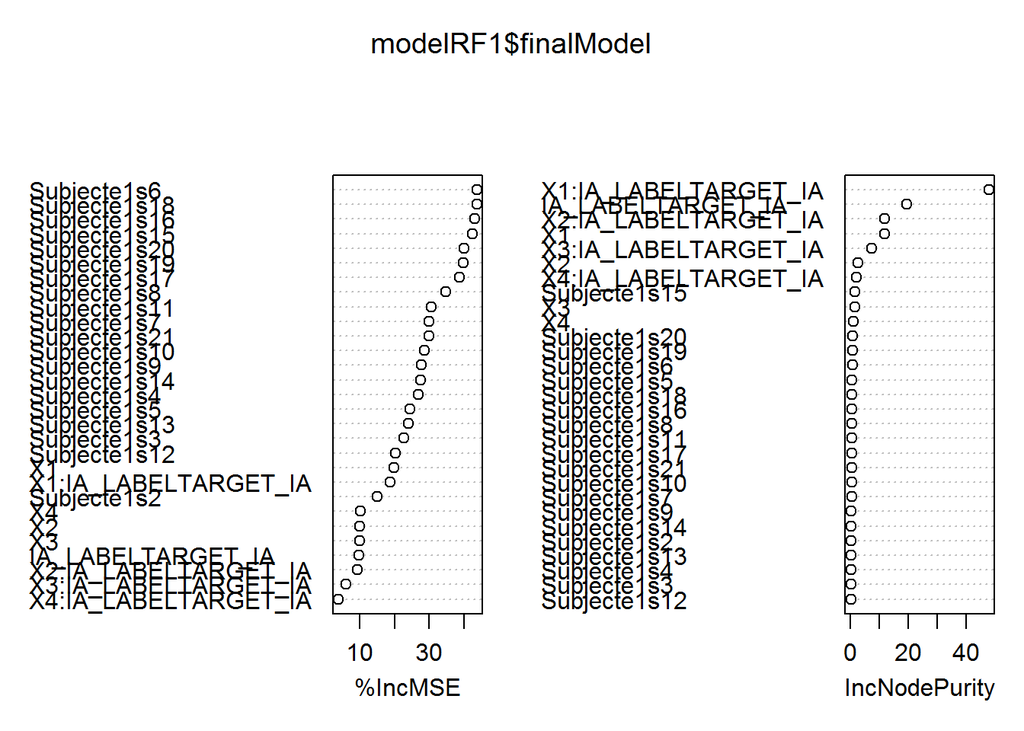

```r
varImpPlot(modelRF1$finalModel)
```

```r
#Examine RMSE
RMSERandomForest<-sqrt(mean((model$Prob-modelRF1$finalModel$predicted)^2))

#attach the predicted values to the dataset for later graphing purposes
model$RF1<-modelRF1$finalModel$predicted
```

The variable importance purity indicator shows that the prediction accuracy is driven primarely by the interaction between linear polynomials and condition. A second model is tested in which higher order polynomials are removed

```r
set.seed(123)
modelRF2<-train(Prob~(X1)*IA_LABEL+Subject, method="rf", data=model,
                trControl = trainControl(method = "cv", number = 5),
                 ntree = 200, importance = TRUE)
#Examine Model Ouput
modelRF2
```

```
## Random Forest
##
## 1554 samples
##   16 predictor
##
## No pre-processing
## Resampling: Cross-Validated (5 fold)
##
## Summary of sample sizes: 1244, 1244, 1242, 1243, 1243
##
## Resampling results across tuning parameters:
##
##   mtry  RMSE        Rsquared   RMSE SD      Rsquared SD
##    2    0.11612704  0.9053073  0.003152801  0.006633397
##   12    0.04388792  0.9748370  0.001819657  0.002732535
##   23    0.04118655  0.9775091  0.002670759  0.003194958
##
## RMSE was used to select the optimal model using  the smallest value.
## The final value used for the model was mtry = 23.
```

```r
#Examine the best model
modelRF2$finalModel
```

```
##
## Call:
##  randomForest(x = x, y = y, ntree = 200, mtry = param$mtry, importance = TRUE)
##                Type of random forest: regression
##                      Number of trees: 200
## No. of variables tried at each split: 23
##
##           Mean of squared residuals: 0.001207258
##                     % Var explained: 98.37
```

```r
#Examine Variable Importance
modelRF2$finalModel$importance
```

```
##                            %IncMSE IncNodePurity
## X1                    0.0263431451    18.9982823
## IA_LABELTARGET_IA     0.0162106289     3.9811630
## Subjecte1s10          0.0004698762     0.4380851
## Subjecte1s11          0.0007035299     0.4329164
## Subjecte1s12          0.0004523743     0.1938466
## Subjecte1s13          0.0005488396     0.2839649
## Subjecte1s14          0.0006040545     0.3023428
## Subjecte1s15          0.0018159690     1.3624555
## Subjecte1s16          0.0008130867     0.5510455
## Subjecte1s17          0.0006856555     0.4718771
## Subjecte1s18          0.0006939834     0.5695125
## Subjecte1s19          0.0008049088     0.7577921
## Subjecte1s2           0.0003685019     0.2960942
## Subjecte1s20          0.0013614798     0.7000462
## Subjecte1s21          0.0008731684     0.4504992
## Subjecte1s3           0.0004186567     0.2319023
## Subjecte1s4           0.0005424074     0.2512136
## Subjecte1s5           0.0005829604     0.5239093
## Subjecte1s6           0.0015354205     0.7511833
## Subjecte1s7           0.0007924462     0.3280914
## Subjecte1s8           0.0006280045     0.5011441
## Subjecte1s9           0.0006636588     0.2840001
## X1:IA_LABELTARGET_IA  0.1357819548    82.2076958
```

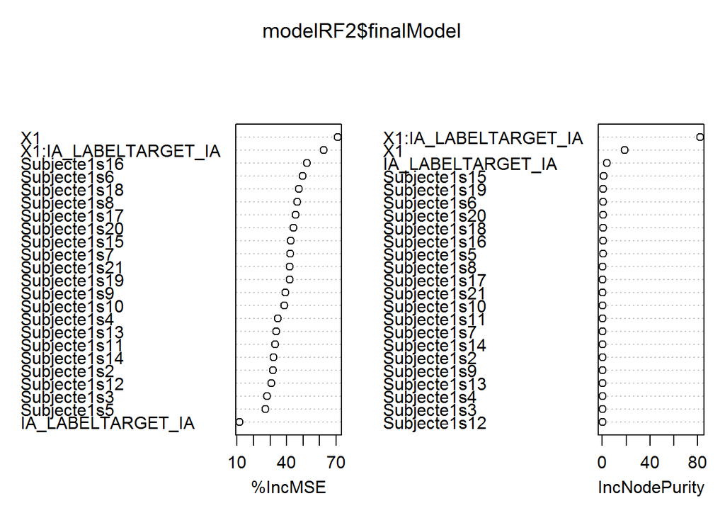

```r
varImpPlot(modelRF2$finalModel)
```

```r
#Examine RMSE
sqrt(mean((model$Prob-modelRF2$finalModel$predicted)^2))
```

```
## [1] 0.03474562
```

```r
#attach the predicted values to the dataset
model$RF2<-modelRF2$finalModel$predicted
```

Interestingly, cross-validation with a simpler random forest model shows a better accuracy on outside samples than the more complex model. It is very likely that using a large number of higher order polynomials leads to overfitting in the case of LMER. A suggestion would be to use model 2 as the model that best describes the data

### *Competitor vs. Distractor*

The required subset for the `2nd` analysis is created. This analysis compares the competitor to the average of the two distarctors

```r
#find proportion for each interest area for each subject
levels(CleanData$IA_LABEL) <- list(Distractor="UNREL1_IA ", Distractor="UNREL2_IA ",Competitor="COMPET_IA ", Target="Target_IA ")

CleanDataProb2<-CleanData %>% group_by(Subject,Bilingual,IA_LABEL,trialtype,time) %>%
    summarise(Prob=mean(value))
CleanDataProb2$time<-as.numeric(as.character(CleanDataProb2$time))

modelData<-CleanDataProb2 %>%
    filter(trialtype=="Experimental", IA_LABEL=="Competitor" | IA_LABEL=="Distractor",
           time>=3100 & time <=4000)
modelData$IA_LABEL<-as.factor(as.character(modelData$IA_LABEL))

#Generate time polynomials up to quadratic poly.
t25 <- data.frame(poly(unique(modelData$time),4))
t25$time <- seq(3100, 4000, by=25)

#add polynomials to data frame
modelData <- merge(modelData , t25, by="time")
head(modelData)
```

```
##   time Subject Bilingual   IA_LABEL    trialtype       Prob         X1
## 1 3100    e1s1        no Distractor Experimental 0.19696970 -0.2771528
## 2 3100   e1s13       yes Distractor Experimental 0.19444444 -0.2771528
## 3 3100    e1s2        no Competitor Experimental 0.05555556 -0.2771528
## 4 3100   e1s14        no Competitor Experimental 0.11111111 -0.2771528
## 5 3100   e1s12        no Competitor Experimental 0.16666667 -0.2771528
## 6 3100    e1s6        no Distractor Experimental 0.20833333 -0.2771528
##          X2        X3        X4
## 1 0.3389575 -0.369759 0.3761457
## 2 0.3389575 -0.369759 0.3761457
## 3 0.3389575 -0.369759 0.3761457
## 4 0.3389575 -0.369759 0.3761457
## 5 0.3389575 -0.369759 0.3761457
## 6 0.3389575 -0.369759 0.3761457
```

```r
str(modelData)
```

```
## 'data.frame':    1554 obs. of  10 variables:
##  $ time     : num  3100 3100 3100 3100 3100 3100 3100 3100 3100 3100 ...
##  $ Subject  : Factor w/ 21 levels "e1s1","e1s10",..: 1 5 12 6 4 18 6 10 17 11 ...
##  $ Bilingual: Factor w/ 2 levels "no","yes": 1 2 1 1 1 1 1 1 1 1 ...
##  $ IA_LABEL : Factor w/ 2 levels "Competitor","Distractor": 2 2 1 1 1 2 2 2 1 1 ...
##  $ trialtype: Factor w/ 4 levels "Experimental",..: 1 1 1 1 1 1 1 1 1 1 ...
##  $ Prob     : num  0.197 0.1944 0.0556 0.1111 0.1667 ...
##  $ X1       : num  -0.277 -0.277 -0.277 -0.277 -0.277 ...
##  $ X2       : num  0.339 0.339 0.339 0.339 0.339 ...
##  $ X3       : num  -0.37 -0.37 -0.37 -0.37 -0.37 ...
##  $ X4       : num  0.376 0.376 0.376 0.376 0.376 ...
```

### *Run Growth Curve Analyses*

The following models are run, with increasing complexity: Model 1: A base model with no polynomials and only with the fixed effect IA_LABEL and random effect of subject intercept and nested condition with subject intercept.

Model 2: Base model with the addition of the linear polynomial for the fixed and random effect structure

Model 3. Model above+the addition of the quadratic polynomial in the fixed effect and random effect structure

Model 4. Model 3+addition of the third poly in the fixed and random effect structure.

Model 5. Model 4+addition of the fourth poly in the fixed and in the random structure. Model fails to converge

Model 6. Model 5+addition of the fourth poly in the subject random effect structure.

Model 7. Model 7+addition of the fourth poly in the subject:condition random effect structure

```r
registerDoParallel(3)
#base model; Model1
Model1<-lmer(Prob ~ IA_LABEL +
                 (1| Subject) +
                 (1| Subject:IA_LABEL),
               data=modelData, REML=T)
#linear; model 2
Model2<-lmer(Prob ~ IA_LABEL*X1 +
                 (1+X1| Subject) +
                 (1+X1| Subject:IA_LABEL),
               data=modelData, REML=T)
#linea+quadratic; model 3
Model3<-lmer(Prob ~ IA_LABEL*(X1+X2) +
                 (1+X1+X2| Subject) +
                 (1+X1+X2| Subject:IA_LABEL),
               data=modelData, REML=T)
#Model 4
Model4<-lmer(Prob ~ IA_LABEL*(X1+X2+X3) +
                 (1+X1+X2+X3| Subject) +
                 (1+X1+X2+X3| Subject:IA_LABEL),
               data=modelData, REML=T)
#Model 5
Model5<-lmer(Prob ~ IA_LABEL*(X1+X2+X3+X4) +
                 (1+X1+X2+X3+X4| Subject) +
                 (1+X1+X2+X3+X4| Subject:IA_LABEL),
               data=modelData, REML=T)
#Model 6
Model6<-lmer(Prob ~ IA_LABEL*(X1+X2+X3+X4) +
                 (1+X1+X2+X3+X4| Subject) +
                 (1+X1+X2+X3| Subject:IA_LABEL),
               data=modelData, REML=T)
#Model 7
Model7<-lmer(Prob ~ IA_LABEL*(X1+X2+X3+X4) +
                 (1+X1+X2+X3| Subject) +
                 (1+X1+X2+X3+X4| Subject:IA_LABEL),
               data=modelData, REML=T)
#compare the models based on ANOVA test
anova(Model1,Model2,Model3,Model4,Model5,Model6, Model7)
```

```
## refitting model(s) with ML (instead of REML)
```

```
## Data: modelData
## Models:
## object: Prob ~ IA_LABEL + (1 | Subject) + (1 | Subject:IA_LABEL)
## ..1: Prob ~ IA_LABEL * X1 + (1 + X1 | Subject) + (1 + X1 | Subject:IA_LABEL)
## ..2: Prob ~ IA_LABEL * (X1 + X2) + (1 + X1 + X2 | Subject) + (1 +
## ..2:     X1 + X2 | Subject:IA_LABEL)
## ..3: Prob ~ IA_LABEL * (X1 + X2 + X3) + (1 + X1 + X2 + X3 | Subject) +
## ..3:     (1 + X1 + X2 + X3 | Subject:IA_LABEL)
## ..5: Prob ~ IA_LABEL * (X1 + X2 + X3 + X4) + (1 + X1 + X2 + X3 + X4 |
## ..5:     Subject) + (1 + X1 + X2 + X3 | Subject:IA_LABEL)
## ..6: Prob ~ IA_LABEL * (X1 + X2 + X3 + X4) + (1 + X1 + X2 + X3 | Subject) +
## ..6:     (1 + X1 + X2 + X3 + X4 | Subject:IA_LABEL)
## ..4: Prob ~ IA_LABEL * (X1 + X2 + X3 + X4) + (1 + X1 + X2 + X3 + X4 |
## ..4:     Subject) + (1 + X1 + X2 + X3 + X4 | Subject:IA_LABEL)
##        Df     AIC     BIC logLik deviance     Chisq Chi Df Pr(>Chisq)
## object  5 -3199.6 -3172.9 1604.8  -3209.6
## ..1    11 -4856.7 -4797.9 2439.4  -4878.7 1669.0985      6     <2e-16 ***
## ..2    19 -5374.6 -5273.0 2706.3  -5412.6  533.8378      8     <2e-16 ***
## ..3    29 -6229.0 -6073.9 3143.5  -6287.0  874.4638     10     <2e-16 ***
## ..5    36 -6337.4 -6144.9 3204.7  -6409.4  122.3747      7     <2e-16 ***
## ..6    36 -6505.4 -6312.9 3288.7  -6577.4  168.0140      0     <2e-16 ***
## ..4    41 -6495.5 -6276.2 3288.8  -6577.5    0.0891      5     0.9999
## ---
## Signif. codes:  0 '***' 0.001 '**' 0.01 '*' 0.05 '.' 0.1 ' ' 1
```

```r
#compare the models based on R^2 based on a paper from Xu (http://onlinelibrary.wiley.com/doi/10.1002/sim.1572/abstract)
1-var(residuals(Model1))/(var(model.response(model.frame(Model1))))
```

```
## [1] 0.28314
```

```r
1-var(residuals(Model2))/(var(model.response(model.frame(Model2))))
```

```
## [1] 0.7802594
```

```r
1-var(residuals(Model3))/(var(model.response(model.frame(Model3))))
```

```
## [1] 0.8594391
```

```r
1-var(residuals(Model4))/(var(model.response(model.frame(Model4))))
```

```
## [1] 0.9295423
```

```r
1-var(residuals(Model5))/(var(model.response(model.frame(Model5))))
```

```
## [1] 0.9458565
```

```r
1-var(residuals(Model6))/(var(model.response(model.frame(Model6))))
```

```
## [1] 0.9375308
```

```r
1-var(residuals(Model7))/(var(model.response(model.frame(Model7))))
```

```
## [1] 0.9458567
```

```r
#find the summary for model 7
summary(Model7)
```

```
## Linear mixed model fit by REML t-tests use Satterthwaite approximations
##   to degrees of freedom [lmerMod]
## Formula:
## Prob ~ IA_LABEL * (X1 + X2 + X3 + X4) + (1 + X1 + X2 + X3 | Subject) +
##     (1 + X1 + X2 + X3 + X4 | Subject:IA_LABEL)
##    Data: modelData
##
## REML criterion at convergence: -6510
##
## Scaled residuals:
##     Min      1Q  Median      3Q     Max
## -4.0276 -0.4523 -0.0221  0.4387  4.2889
##
## Random effects:
##  Groups           Name        Variance  Std.Dev. Corr
##  Subject:IA_LABEL (Intercept) 0.0004241 0.02059
##                   X1          0.0174160 0.13197  -0.56
##                   X2          0.0147778 0.12156  -0.17 -0.37
##                   X3          0.0083242 0.09124   0.27 -0.25 -0.58
##                   X4          0.0048104 0.06936  -0.01  0.26 -0.60 -0.11
##  Subject          (Intercept) 0.0002566 0.01602
##                   X1          0.0001417 0.01190   0.28
##                   X2          0.0003117 0.01765  -0.15  0.91
##                   X3          0.0002705 0.01645  -0.82  0.31  0.68
##  Residual                     0.0005996 0.02449
## Number of obs: 1554, groups:  Subject:IA_LABEL, 42; Subject, 21
##
## Fixed effects:
##                        Estimate Std. Error        df t value Pr(>|t|)
## (Intercept)            0.149452   0.005760 35.180000  25.944  < 2e-16 ***
## IA_LABELDistractor    -0.093387   0.006475 23.630000 -14.422 3.31e-13 ***
## X1                    -0.501280   0.029405 40.060000 -17.048  < 2e-16 ***
## X2                    -0.117886   0.027333 40.210000  -4.313 0.000102 ***
## X3                     0.177112   0.020924 40.050000   8.464 1.86e-10 ***
## X4                    -0.042866   0.016050 40.000000  -2.671 0.010890 *
## IA_LABELDistractor:X1  0.230970   0.041422 39.310000   5.576 1.96e-06 ***
## IA_LABELDistractor:X2  0.234846   0.038269 39.190000   6.137 3.28e-07 ***
## IA_LABELDistractor:X3 -0.219000   0.029153 38.930000  -7.512 4.34e-09 ***
## IA_LABELDistractor:X4  0.054049   0.022699 40.000000   2.381 0.022108 *
## ---
```

[output cut: 8 more lines]

```
## X4           -0.009  0.008      0.242 -0.546 -0.098
## IA_LABELD:X1  0.306 -0.545     -0.704  0.251  0.163 -0.172
## IA_LABELD:X2  0.091 -0.162      0.252 -0.700  0.384  0.390 -0.358
## IA_LABELD:X3 -0.142  0.252      0.165  0.386 -0.697  0.070 -0.234
## IA_LABELD:X4  0.006 -0.011     -0.171  0.386  0.069 -0.707  0.243
##              IA_LABELD:X2 IA_LABELD:X3
## IA_LABELDst
## X1
## X2
## X3
## X4
## IA_LABELD:X1
## IA_LABELD:X2
## IA_LABELD:X3 -0.551
## IA_LABELD:X4 -0.552       -0.099
```

```r
#find the RMSE
sqrt(mean((modelData$Prob-fitted(Model7))^2))
```

```
## [1] 0.02308168
```

```r
#attach the fitted values to the dataset modelData, so that they can be used later for graphing purposes
modelData$Model1Fitted<-fitted(Model1)
modelData$Model2Fitted<-fitted(Model2)
modelData$Model3Fitted<-fitted(Model3)
modelData$Model4Fitted<-fitted(Model4)
modelData$Model5Fitted<-fitted(Model5)
modelData$Model6Fitted<-fitted(Model6)
modelData$Model7Fitted<-fitted(Model7)
```

Model 7 seems to perform the best, while also converging to a result. Next, I will examine what happens in random forests.

The first models examines the inclusion of all 4 polynomials interacting with the IA_LABEL and the inclusion of Subject ID

```r
set.seed(123)
modelRF1<-train(Prob~(X1+X2+X3+X4)*IA_LABEL+Subject, method="rf", data=modelData,
                trControl = trainControl(method = "cv", number = 5),
                 ntree = 200, importance = TRUE)
#Examine Model Ouput
modelRF1
```

```
## Random Forest
##
## 1554 samples
##   16 predictor
##
## No pre-processing
## Resampling: Cross-Validated (5 fold)
##
## Summary of sample sizes: 1244, 1243, 1244, 1242, 1243
##
## Resampling results across tuning parameters:
##
##   mtry  RMSE        Rsquared   RMSE SD      Rsquared SD
##    2    0.05106880  0.7991741  0.005779499  0.02702761
##   15    0.02829593  0.9202621  0.003661273  0.01655177
##   29    0.02820389  0.9201522  0.004249287  0.01955265
##
## RMSE was used to select the optimal model using  the smallest value.
## The final value used for the model was mtry = 29.
```

```r
#Examine the best model
modelRF1$finalModel
```

```
##
## Call:
##  randomForest(x = x, y = y, ntree = 200, mtry = param$mtry, importance = TRUE)
##                Type of random forest: regression
##                      Number of trees: 200
## No. of variables tried at each split: 29
##
##           Mean of squared residuals: 0.000576753
##                     % Var explained: 94.14
```

```r
#Examine Variable Importance
modelRF1$finalModel$importance
```

```
##                            %IncMSE IncNodePurity
## X1                    1.349645e-02    6.08127853
## X2                    1.180153e-03    0.69913063
## X3                    7.325920e-04    0.47836648
## X4                    3.977760e-04    0.30384646
## IA_LABELDistractor    1.920663e-03    0.86124868
## Subjecte1s10          1.595860e-04    0.13814613
## Subjecte1s11          1.000259e-04    0.10527739
## Subjecte1s12          4.944083e-05    0.05732554
## Subjecte1s13          9.232495e-05    0.08395247
## Subjecte1s14          7.989593e-05    0.07475149
## Subjecte1s15          2.286237e-04    0.15948182
## Subjecte1s16          3.326874e-04    0.23057087
## Subjecte1s17          3.928095e-04    0.29326482
## Subjecte1s18          3.069351e-04    0.24786427
## Subjecte1s19          4.213613e-04    0.32621173
## Subjecte1s2           1.256886e-04    0.11302107
## Subjecte1s20          9.706902e-05    0.08369887
## Subjecte1s21          1.507126e-04    0.13030298
## Subjecte1s3           5.252228e-05    0.06413565
## Subjecte1s4           2.010342e-04    0.11888891
## Subjecte1s5           2.243356e-05    0.04755376
## Subjecte1s6           5.316827e-05    0.06610493
## Subjecte1s7           2.017088e-04    0.15212121
## Subjecte1s8           3.363457e-04    0.21841501
## Subjecte1s9           2.091854e-04    0.19042402
## X1:IA_LABELDistractor 1.060983e-03    0.50932439
## X2:IA_LABELDistractor 4.797565e-04    0.27826418
## X3:IA_LABELDistractor 4.989781e-03    2.85684587
## X4:IA_LABELDistractor 1.903569e-04    0.10034923
```

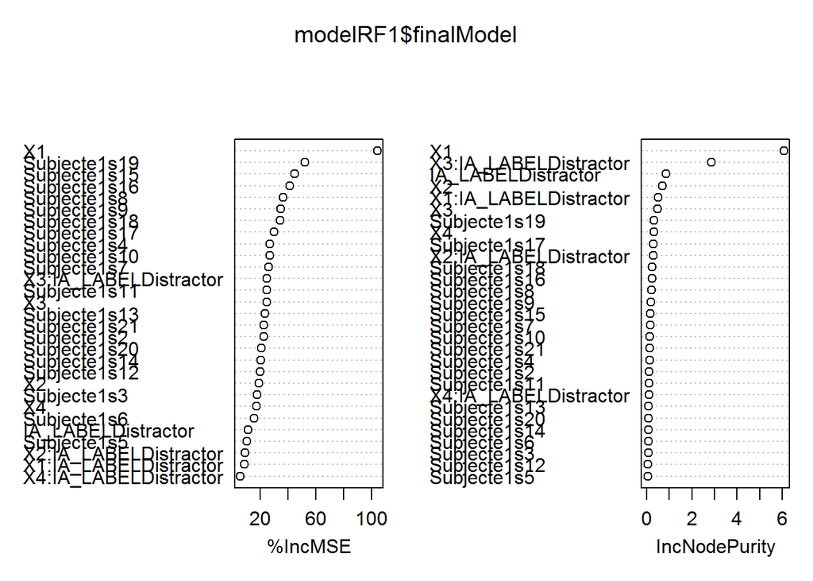

```r
varImpPlot(modelRF1$finalModel)
```

```r
#Examine RMSE
RMSERandomForest<-sqrt(mean((model$Prob-modelRF1$finalModel$predicted)^2))
#attach predicted values
modelData$RF1<-modelRF1$finalModel$predicted
```

```r
set.seed(123)
modelRF2<-train(Prob~(X1)*IA_LABEL+Subject, method="rf", data=modelData,
                trControl = trainControl(method = "cv", number = 5),
                 ntree = 200, importance = TRUE)
#Examine Model Ouput
modelRF2
```

```
## Random Forest
##
## 1554 samples
##   17 predictor
##
## No pre-processing
## Resampling: Cross-Validated (5 fold)
##
## Summary of sample sizes: 1244, 1243, 1244, 1242, 1243
##
## Resampling results across tuning parameters:
##
##   mtry  RMSE        Rsquared   RMSE SD      Rsquared SD
##    2    0.06112216  0.7530051  0.006406314  0.03746764
##   12    0.02627081  0.9320485  0.003055935  0.01192364
##   23    0.02494897  0.9378480  0.003258758  0.01371083
##
## RMSE was used to select the optimal model using  the smallest value.
## The final value used for the model was mtry = 23.
```

```r
#Examine the best model
modelRF2$finalModel
```

```
##
## Call:
##  randomForest(x = x, y = y, ntree = 200, mtry = param$mtry, importance = TRUE)
##                Type of random forest: regression
##                      Number of trees: 200
## No. of variables tried at each split: 23
##
##           Mean of squared residuals: 0.000440317
##                     % Var explained: 95.53
```

```r
#Examine Variable Importance
modelRF2$finalModel$importance
```

```
##                            %IncMSE IncNodePurity
## X1                    1.552685e-02    7.47423713
## IA_LABELDistractor    3.862734e-03    1.72782931
## Subjecte1s10          1.812441e-04    0.16217118
## Subjecte1s11          1.176809e-04    0.11178808
## Subjecte1s12          5.707618e-05    0.06175079
## Subjecte1s13          9.978810e-05    0.08045461
## Subjecte1s14          9.439683e-05    0.07064084
## Subjecte1s15          2.248166e-04    0.16532935
## Subjecte1s16          3.519084e-04    0.24322761
## Subjecte1s17          4.878238e-04    0.32071937
## Subjecte1s18          3.714003e-04    0.26016881
## Subjecte1s19          4.189579e-04    0.31372541
## Subjecte1s2           1.656492e-04    0.12406211
## Subjecte1s20          1.092233e-04    0.08854760
## Subjecte1s21          1.639618e-04    0.15069758
## Subjecte1s3           6.166943e-05    0.06507582
## Subjecte1s4           2.195251e-04    0.11648428
## Subjecte1s5           2.336434e-05    0.04716312
## Subjecte1s6           6.054355e-05    0.07685772
## Subjecte1s7           2.542759e-04    0.16955172
## Subjecte1s8           3.811355e-04    0.24934386
## Subjecte1s9           2.165648e-04    0.17936693
## X1:IA_LABELDistractor 5.141166e-03    2.75721044
```

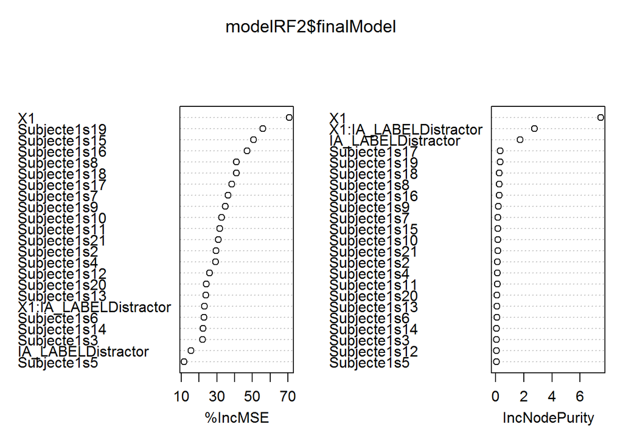

```r
varImpPlot(modelRF2$finalModel)
```

```r
#Examine RMSE
sqrt(mean((modelData$Prob-modelRF2$finalModel$predicted)^2))
```

```
## [1] 0.02098373
```

```r
#attached predicted values
modelData$RF2<-modelRF2$finalModel$predicted
```

## **Graphs**

Each model used above will be graphed by overlaying it on the real data. First, the plots for the first comparison will be created. For this, I use the model dataset. I put the data in long only format.

```r
ModelLong<- model %>% gather(Model,Predictions,11:18)
#rename the competitor and target
levels(ModelLong$IA_LABEL) <- list(Competitor="COMPET_IA ", Target="TARGET_IA ")
#rename the models so that they are more clear
levels(ModelLong$Model) <- list(`Model 1 Intercept`="Model1Fitted", `Model 2 Linear`="Model2Fitted", `Model 3 Quadratic`="Model3Fitted", `Model 4 Cubic (not converged)`="Model4Fitted", `Model 5 Cubic`="Model5Fitted", `Model 6 Cubic`="Model6Fitted", `Random Forest Complex`="RF1",`Random Forest Simple`="RF2")

#rename some of the colums
colnames(ModelLong)[4]<-"Interest Area"
ModelLong[,4]<-factor(ModelLong[,4])
#compress the data(find the average over subjects)
ForGraph1<-ModelLong %>% group_by(`Interest Area`,time, Model) %>%
    summarise(`Fixation Probability`=mean(Prob),Predicted=mean(Predictions))
```

The code chunk below will plot and save the graph

```r
#color palette for color-blind
cbPalette <- c("#999999", "#E69F00", "#56B4E9", "#009E73", "#F0E442", "#0072B2", "#D55E00", "#CC79A7")
#create plot1 for Experiment 1, which goes in the publication
png(filename="plot1Experiment1.png",width=900,height=524)
ggplot(ForGraph1, aes(x=time, y=`Fixation Probability`, shape=`Interest Area`, color=`Interest Area`)) +
    geom_point(size=3) + geom_line(aes(y=Predicted), size=1)+facet_wrap(~Model, nrow=2, ncol=4)+
    scale_fill_manual(values=cbPalette)+scale_colour_manual(values=cbPalette)+
    ggtitle("Fixation Proportion for Models\n examining Target vs. Competitor")+
    theme_bw()+
    scale_x_continuous(name="time 200ms after spoken word onset(ms)")+
    theme(legend.text = element_text(size = 12))+
    theme(legend.title = element_text(size=12, face="bold"))+
    theme(axis.title.x = element_text(face="bold", size=15), axis.text.x  = element_text(size=12))+
    theme(axis.title.y = element_text(face="bold", size=15), axis.text.y  = element_text(size=12))+
    theme(strip.text.x = element_text(size=12, face="bold"))+
    theme(plot.title = element_text(lineheight=.8, face="bold", size=14))
dev.off()
```

Now I will plot the second graph for Competitor vs. average of the two distractors. I will use the same steps as for the graph above

```r
ModelLong<- modelData %>% gather(Model,Predictions,11:19)
#rename the models so that they are more clear
levels(ModelLong$Model) <- list(`Model 1 Intercept`="Model1Fitted", `Model 2 Linear`="Model2Fitted", `Model 3 Quadratic`="Model3Fitted", `Model 4 Cubic`="Model4Fitted", `Model 5 Quartic (not converged)`="Model5Fitted", `Model 6 Quartic`="Model6Fitted",`Model 7 Quartic`="Model7Fitted",`Random Forest Complex`="RF1",`Random Forest Simple`="RF2")

#rename some of the colums
colnames(ModelLong)[4]<-"Interest Area"
ModelLong[,4]<-factor(ModelLong[,4])
#compress the data(find the average over subjects)
ForGraph2<-ModelLong %>% group_by(`Interest Area`,time, Model) %>%
    summarise(`Fixation Probability`=mean(Prob),Predicted=mean(Predictions))
```

The code chunk below will plot and save the graph

```r
#color palette for color-blind
cbPalette <- c("#999999", "#E69F00", "#56B4E9", "#009E73", "#F0E442", "#0072B2", "#D55E00", "#CC79A7")
#create plot1 for Experiment 1, which goes in the publication
png(filename="plot2Experiment1.png",width=900,height=524)
ggplot(ForGraph2, aes(x=time, y=`Fixation Probability`, shape=`Interest Area`, color=`Interest Area`)) +
    geom_point(size=3) + geom_line(aes(y=Predicted), size=1)+facet_wrap(~Model, nrow=3, ncol=3)+
    scale_fill_manual(values=cbPalette)+scale_colour_manual(values=cbPalette)+
    ggtitle("Fixation Proportion for Models\n examining Target vs. Competitor")+
    theme_bw()+
    scale_x_continuous(name="time 200ms after spoken word onset(ms)")+
    theme(legend.text = element_text(size = 12))+
    theme(legend.title = element_text(size=12, face="bold"))+
    theme(axis.title.x = element_text(face="bold", size=15), axis.text.x  = element_text(size=12))+
    theme(axis.title.y = element_text(face="bold", size=15), axis.text.y  = element_text(size=12))+
    theme(strip.text.x = element_text(size=12, face="bold"))+
    theme(plot.title = element_text(lineheight=.8, face="bold", size=14))
dev.off()
```